# PCFL 2021: Week 6 wrap-up

### Last week’s games

| Away | Away points | Home | Home points |
| --- | --- | --- | --- |
| KC Gophers | 105.78 | The G.O.A.T. | 80.40 |
| Middle Earth Hangry Hobbits | 121.74 | Athens Team Sasquatch | 142.92 |
| The Sophomores TSoph | 131.10 | Jumpin’ Jaheims | 110.57 |
| Southern Sharks | 128.60 | Pigskin on the Gridiron | 95.38 |
| Georgia Peanuts | 100.05 | Captain Clairvoyant | 124.38 |

I tried adding a predicted spread from last week, and that went 1-4 (only got The Sophomores correct). So that’s…something?

#### Best performing players

Here’s last week’s **10 best performing players.**

| Player | Points | Team |
| --- | --- | --- |
| Derrick Henry | 34.60 | Middle Earth Hangry Hobbits |
| CeeDee Lamb | 31.60 | Athens Team Sasquatch |
| Cooper Kupp | 29.90 | Pigskin on the Gridiron |
| Josh Allen | 28.72 | Athens Team Sasquatch |
| Kirk Cousins | 28.52 | Southern Sharks |
| Jonathan Taylor | 28.30 | Captain Clairvoyant |
| Leonard Fournette | 27.70 | Pigskin on the Gridiron |
| Dak Prescott | 26.80 | The G.O.A.T. |
| Jaylen Waddle | 25.90 | Middle Earth Hangry Hobbits |
| Kyler Murray | 25.76 | Athens Team Sasquatch |

Y’all may not have watched Derrick Henry on Monday night, but the man is unreal (and this week’s top scorer). CeeDee Lamb and Cooper Kupp round out a top 3 without a QB in sight.

#### Best addition and top bench

There were 20 players added last week. Which was the **best new addition**?

| Date added | Name | Points | Team |
| --- | --- | --- | --- |
| 2021-10-16 | Jaylen Waddle | 25.90 | Middle Earth Hangry Hobbits |
| 2021-10-13 | Darrel Williams | 22.40 | Athens Team Sasquatch |
| 2021-10-13 | Khalil Herbert | 18.20 | Georgia Peanuts |
| 2021-10-17 | Carson Wentz | 17.02 | Jumpin’ Jaheims |
| 2021-10-17 | Alex Collins | 16.30 | Jumpin’ Jaheims |
| 2021-10-14 | Matt Prater | 15.00 | Captain Clairvoyant |
| 2021-10-16 | Chris Boswell | 13.00 | Athens Team Sasquatch |
| 2021-10-16 | Latavius Murray | 12.60 | Southern Sharks |
| 2021-10-13 | Greg Zuerlein | 12.00 | Southern Sharks |
| 2021-10-13 | Zach Ertz | 10.90 | Athens Team Sasquatch |
| 2021-10-17 | Jared Cook | 10.50 | Jumpin’ Jaheims |
| 2021-10-13 | Taylor Heinicke | 9.28 | Pigskin on the Gridiron |
| 2021-10-14 | Miles Sanders | 7.60 | Athens Team Sasquatch |
| 2021-10-15 | AJ Dillon | 5.90 | Georgia Peanuts |
| 2021-10-13 | Kadarius Toney | 5.10 | Georgia Peanuts |
| 2021-10-13 | Nick Folk | 3.00 | Athens Team Sasquatch |
| 2021-10-13 | Chase Claypool | 2.70 | Athens Team Sasquatch |
| 2021-10-14 | Alexander Mattison | 1.00 | Pigskin on the Gridiron |
| 2021-10-14 | Kenneth Gainwell | 0.60 | Pigskin on the Gridiron |
| 2021-10-14 | Matt Ryan | 0.00 | Captain Clairvoyant |

Injuries plus bye weeks means the most active transaction wire this season. Of all the new pickups, though, only Jaylen Waddle and Darrel Williams broke the 20 point mark.

Who won the **best scoring bench** award last week?

| Team | Points |
| --- | --- |
| Southern Sharks | 112.42 |
| Middle Earth Hangry Hobbits | 68.96 |
| Athens Team Sasquatch | 62.92 |
| Jumpin’ Jaheims | 61.14 |
| KC Gophers | 57.30 |
| Captain Clairvoyant | 55.40 |
| Pigskin on the Gridiron | 51.58 |
| The Sophomores TSoph | 50.64 |
| Georgia Peanuts | 44.60 |
| The G.O.A.T. | 37.66 |

### League standings and season stats

Here’s a look at the current standings.

| Team | Division | W | L | Points scored | Points allowed | Points rank | Playoff rank |
| --- | --- | --- | --- | --- | --- | --- | --- |
| The Sophomores TSoph | Hot Dish | 5 | 1 | 745.64 | 656.10 | 2 | 1 |
| Pigskin on the Gridiron | Grits | 4 | 2 | 711.32 | 690.95 | 4 | 2 |
| Captain Clairvoyant | Grits | 4 | 2 | 693.06 | 673.99 | 5 | 3 |
| Georgia Peanuts | Hot Dish | 4 | 2 | 659.44 | 643.73 | 8 | 4 |
| Athens Team Sasquatch | Grits | 3 | 3 | 752.30 | 749.14 | 1 | 5 |
| Jumpin’ Jaheims | Grits | 3 | 3 | 671.85 | 677.93 | 7 | 6 |
| Middle Earth Hangry Hobbits | Hot Dish | 2 | 4 | 727.28 | 699.90 | 3 | 7 |
| Southern Sharks | Hot Dish | 2 | 4 | 682.80 | 746.94 | 6 | 8 |
| KC Gophers | Hot Dish | 2 | 4 | 626.88 | 663.74 | 9 | 9 |
| The G.O.A.T. | Grits | 1 | 5 | 579.22 | 647.37 | 10 | 10 |

Here’s our current awards leaders from these standings:

- Yellow shirt (most points): Team Sasquatch *new*
- D-FENCE (least points allowed): Georgia Peanuts
- Tough luck (points rank - playoff rank): Team Sasquatch AND Middle Earth Hangry Hobbits–first (!) and third in points, but only fifth and seventh in the rankings.
- Lucky ducks (playoff rank - points rank): The Georgia Peanuts–fourth in playoff rankings but eighth in points. Better lucky than good!

Here’s a list of the **top five scoring performances** so far this season.

| Team | Week | Points scored | Result |
| --- | --- | --- | --- |
| Georgia Peanuts | 5 | 158.97 | W |
| The Sophomores TSoph | 4 | 158.62 | W |
| Athens Team Sasquatch | 5 | 149.80 | W |
| The G.O.A.T. | 4 | 149.52 | W |
| KC Gophers | 1 | 149.28 | W |

No new entries this week.

### Here’s a look at the **points trendline** for each team.

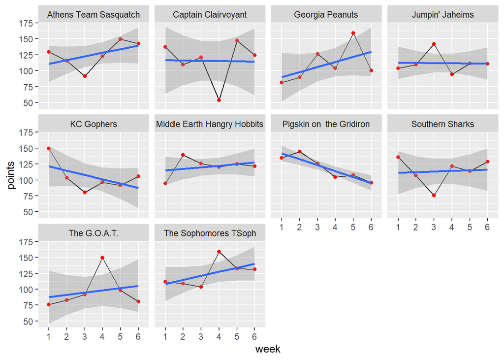

Not a lot of changes from last week in point totals, except for a big drop from the Georgia Peanuts. Sigh.

### If the season ended today…

Our playoff teams would be Erin/Trav, Richard, Brian, and me. Our last place finisher would be Jacob.

### Next week’s preview

| Away team | Last 3 wks avg (away) | Home team | Last 3 wks avg (home) | Line |
| --- | --- | --- | --- | --- |
| The G.O.A.T. | 109.47 | Middle Earth Hangry Hobbits | 122.45 | Middle Earth Hangry Hobbits (+12.98) |
| Athens Team Sasquatch | 138.53 | The Sophomores TSoph | 140.63 | The Sophomores TSoph (+2.1) |
| Jumpin’ Jaheims | 105.52 | Southern Sharks | 121.50 | Southern Sharks (+15.98) |
| Pigskin on the Gridiron | 102.37 | Georgia Peanuts | 120.90 | Georgia Peanuts (+18.53) |
| Captain Clairvoyant | 108.46 | KC Gophers | 97.86 | Captain Clairvoyant (+10.6) |

Two high scorers go head to head with Team Sasquatch vs. the Sophomores in our game of the week. Scott, Sarah, Brian, and I are also favored. Good luck, y’all!